# IntroR

Diego J. Bodas Sagi

27 Sept 2016

[figure not shown]

# Basic R Markdown

Install the rmarkdown package

This is a latex equation, $E = mc^{2}$

This is a inline code `print("this is an inline code")`

Set echo = TRUE if you want to include source code in the output

# Some first Code examples (R course)

R packages implement fuctions. You can install packages from repositories using:

```r
#install.packages('Rcpp', repos = 'http://cran.us.r-project.org')
# commented
```

You have to check installation path or library

## Examples with dev-tools

Why to explain dev-tools? Because, it needs compilation. Devtools is designed for package developers and provide R functions that simplify many common tasks. You need to install dependencies.

### Requisites

On Windows: Install Rtools On Mac: Install Xcode from the Mac App Store On Linux: Install a compiler and various development libraries

### How to install

```r
#install.packages("devtools", type = "source", dependencies = TRUE, repos = 'http://cran.us.r-project.org')
# commented
```

Do not worry if it requires restart the R session.

You can test instalation loading the package.

```r
# library(devtools)
```

Other way to load packages is to use the require function:

```r
# require(devtools)
```

It also works!!!, but what is the different???????

library: if the package can’t be loaded, it returns an error. Require try to load the package, does not return an error.

## Unload a package

You can unload a package using the function *detach()*

```r
# detach("package:devtools", unload = TRUE)
```

## Advance package management, and some data structures and functions ;-)

To install several packages use the following code (note: “<-”):

```r
packages.to.install <- c("plyr", "psych", "tm", "Rcpp", "devtools") # c is a vector
```

But only install the missing packages…

```r
packages.to.install <- c("plyr", "psych", "tm") # c is a vector
new.packages <- packages.to.install[!(packages.to.install %in% installed.packages()[,"Package"])]
if(length(new.packages)) install.packages(new.packages)
# detach() function to unload
```

To apply function to all elements in vector (and load all):

```r
if(length(new.packages)) lapply(new.packages, library, character.only = TRUE)
```

If you want to list all packages in memory:

```r
packages.in.memory <- names(sessionInfo()$otherPkgs)
```

You can see results in *Global Environment*

How to concat or paste a vector in R:

```r
packages.in.memory <- paste('package:', packages.in.memory, sep = "")
```

If you want to print in console:

```r
packages.in.memory
```

```
## [1] "package:"
```

Or print in console

```r
print(packages.in.memory)
```

```
## [1] "package:"
```

And, finally, clean memory

```r
rm(list = ls(all = TRUE))
```

# The eval() function

This function allows to evaluate an expression. For example:

`eval(paste("cadena 1", "cadena 2", sep = ' - '))`

You can also evaluate a string

`eval(parse(text = "2*10"))`

Check the difference

`eval("5+5")`

# The expression() function

You can create your own expressions and evaluate later

```r
x <- expression(sin(pi/2))
x
```

```
## expression(sin(pi/2))
```

```r
eval(x)
```

```
## [1] 1
```

# Basic Plots

In the next class, we are going to work with the ggplot package. Now, an easy graph:

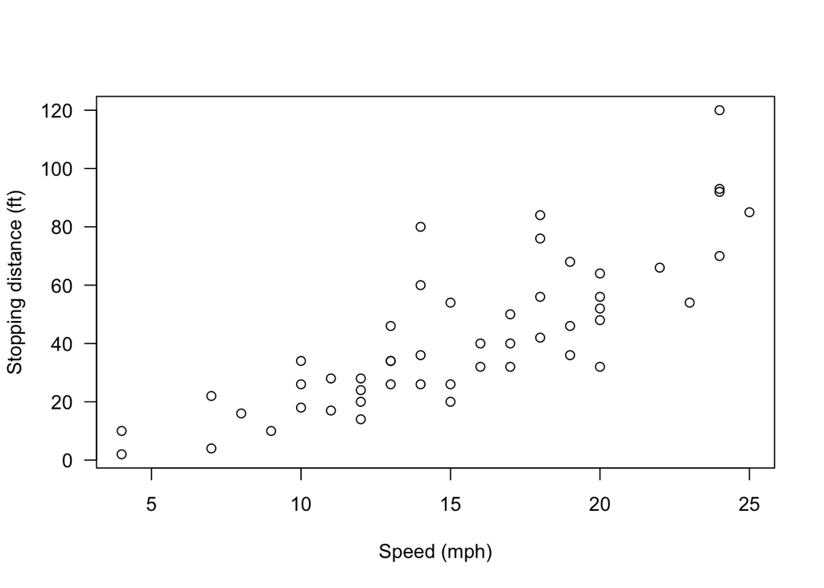

```r
plot(cars, xlab = "Speed (mph)", ylab = "Stopping distance (ft)", las = 1)
```

The end, thanks you.